# YOLO v4 paper

Written by Aaron

2022-05-28

## YOLO v4 : Optimal Speed and Accuracy of Objefct Detection.

#### Reference

[YOLO v4 Paper](https://arxiv.org/pdf/2004.10934v1.pdf)

#### Abstract

- CNN 정확도 개선을 위한 수많은 feature(function)들이 존재
- 어떤 feature들은 특정 model or problem에만 국한되어 동작하거나 소규모 데이터셋에 대해서만 동작하는 것들이 있음
- 반면에 대부분의 model 등에 적용 가능한 universal 한 feature들이 존재함
  - Weighted-Residual-Connections(WRC)
  - Cross-Stage-Partial-connections(CSP)
  - Cross mini-Batch Normalization (CmBN)
  - Self-adversarial-training(SAT)
  - Mish-activation
- 이 논문에서는 아래의 내용에 따라 분석을 진행함.
  - WRC, CSP, CmBN, SAT, Mish-activation, Mosaic data augmentation, DropBlock regularization, CIoU를 조합하여 SOTA 달성.
  - MS COCO data 기준 43.5% AP(65.6% AP<sub>50</sub>)
  - Tesla V100 기준 ~ 65FPS

**YOLO v4** - CSPDarknet53 - SPP + PAN - YOLO v3 - Many BoF + Bos feautres

#### Intro

- 대부분의 CNN 기반 object detection에는 정확도와 속도 간 trade-off가 존재
  - 주차 가능 공간 탐색 : 느리지만 정확한 Model
  - 차량 추돌 경고 : 빠르지만 부정확한 Model
- 본 논문의 목적
  - 누구나 실시간/고품질의 결과를 얻을 수 있도록
  - BFLOP 즉, 연산을 줄이는 게 아니라 생산하는 단계에서 빠른 속도로 동작하는 object detector 고안하고 병렬 최적화

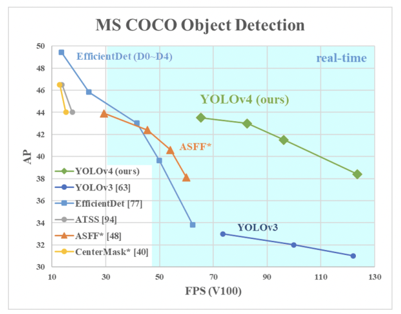

- 본 논문의 결과 기여
  - 보다 강력한 Object detector 개발
  - 최신 Bag-of-freebies, Bag-of-Specials 기법 효과 검증
  - 단일 GPU에 효율적으로 적합하기 위한 최신 기법들을 수정
    - CBN
    - PAN
    - SAM
    - etc..

#### Related work

- Object Detection model
  1. Backbone : ImageNet을 이용한 pre-trained
     - GPU 기반 : VGG, ResNet, ResNeXt, DenseNet, etc
     - CPU 기반 : SqueezeMet. MobileNet, ShuffleNet, etc
  2. Head : class와 BBox prediction에 적용
     - one-stage detector
       - anchor-based : YOLO, SSD, RetinaNet, etc
       - anchor-free : CenterNet, CornetNet, FCOS, etc
     - two-stage detector
       - anchor-based : R-CNN series, etc
       - anchor-free : RedPoints, etc
  3. Neck : backbone과 head 사이에 크고 작은 object detection가 가능하도록 여러 feature map의 특성을 모으는 역할
     - Feature Pyramid Network(FPN), Path Aggregation Network(PAN), BiFPN, NAS-FPN, etc
  4. Others : 새롭게 연구 된 부분
     - 새로운 backbone : DetNet, DetNAS, etc
     - 새로운 모델 구축 : SpineNet, HitDetector, etc

**일반적인 object detection 구조**

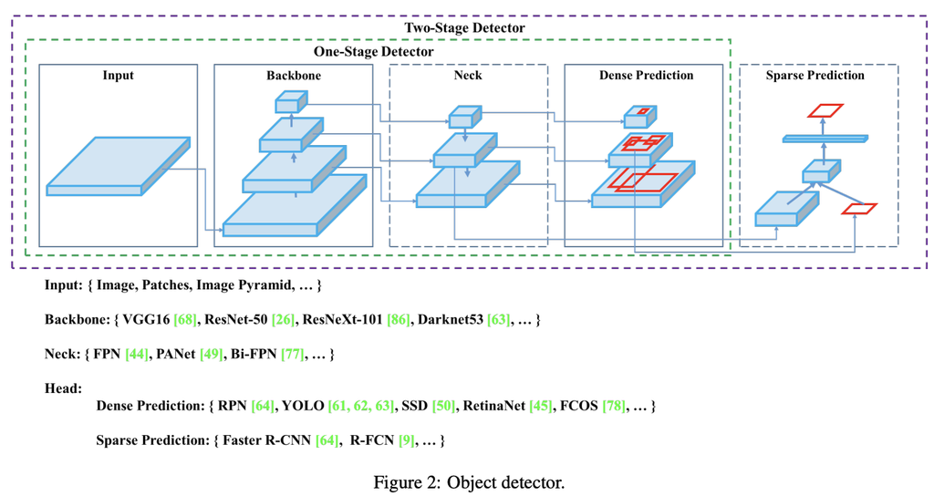

- Bag of Freebies(BoF)
  1. data augmentation
  - input의 가변성을 증가시켜 model이 다른 환경에서 얻은 이미지(resolution 등 quality 차이가 있는)에 대해서도 높은 강건함을 유지하는 것이 목적
    - 광학적, 기하학적, pixel-wise
    - object occlusion 문제에 중점을 연구
    - 여러 이미지를 함께 사용하는 방법
    - style transfer GAN 적용하여 texture bias를 효과적으로 줄임.
  2. regularization
  - data augmentation과 유사한 개념을 feature map에 적용하는 연구
  3. imbalance sampling
     - class imbalance
     - 서로 다른 category 간 연관성을 표현하기 어려운 부분에 대한 연구
  4. objective function(BBox regression) - IoU description page. to be update
     - IoU loss
     - GIoU loss
     - DIoU, CIoU loss
- Bag of Specials(BoS)
  1. plugin modules
     - receptive field enhancement module
       - SPP
       - ASPP
       - REB
     - attention modules
       - Squeeze-and-Excitation(SE)
       - Spatial Attention Module(SAM)
     - feature integration
       - FPN 등
     - activation function : gradient vanish 문제 해결하기 위해
       - ReLU
       - LReLU, PReLU : ReLU의 출력이 0보다 작을 경우 gradient가 0이 되는 문제를 해결
       - ReLU6, hard-Swish : quantization networks를 고려
       - SELU : neural network를 self-normalizing하기 위한 목적
       - Swish, Mish : continuously differentiable activation function
2. post-processing : 일반적으로 NMS(Non-Maximum Suppression)
   - NMS
   - greedy NMS
   - soft NMS, DIoU

###### > anchor-free 기법에서는 post-processing이 필요하지 않음.

#### Methodology

1. Selection of architecture
   - detector 선택 시 고려 사항
     - 더 큰 크기의 input resolution
     - 더많은 layer 수 > 더 큰 receptive field
     - 더 많은 parameter 수 : 서로 다른 크기의 objects들을 검출하기 위해
   - CSPDarknet53에 SPP block 추가
     - receptive field 향상
     - context features 분리
     - network 속도 저하 없음
   - CPSDarknet53에 parameter aggregation 기법으로 PAN 이용

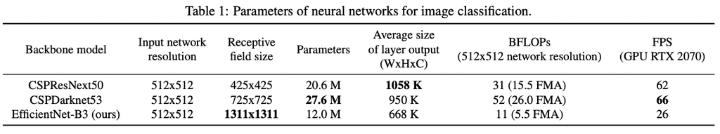

> 최종적으로 선택된 기법들  
> backbone : CSPDarknet53  
> neck  
> - additional blocks : SPP  
> - path-aggregation blocks : PANet  
> head : YOLO v3(anchor-based)
2. Selection of BoF and BoS
- BoF 후보 features
  - BBox regression : MSE, IoU, GIoU, DIoU, CIoU
  - data augmentation : CutOut, MixUp, CutMix
  - regulation method : DropOut, DropPath, Spatial DropOut, DropBlock

###### > DropBlock을 게시한 사람들이 다른 정규화 방법과 비교했을 때 우수한 성능을 보임을 입증

- BoS 후보 features
  - activations : ReLU, leaky-ReLU, parametric ReLU, ReLU6, SELU, Swish, Mish
  - normalization of the network activations
    - Batch Normalization
    - Cross GPU batch Normalization(CGBN or SyncBN) : 본 연구는 하나의 GPU를 이용하는 것이 중점이기 때문에 제외
    - Filter Response Normalization
    - Cross-iteration Batch Normalization
  - skip-connections
    - Residual connections
    - Weighted residual connections
    - Multi-input weighted residual connections
    - Cross stage partial connections(CSP)
3. Additional improvements
- 새롭게 도입한 BoF data augmentation
  - Mosaic
    - 4개의 train image를 1개로 mix
    - batch normalization은 각 layer 상에서 서로 다른 4개의 이미지들에 대한 activation statistic 계산 가능

###### > 큰 크기의 mini-batch에 대한 필요성을 줄일 수 있음.

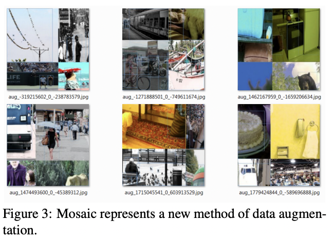

  - SAT(Self-Adversarial Training)
    - 2단계의 forward & backward 단계로 동작
    - 1단계 : network의 weight가 아닌 원본 이미지를 변경

###### > 자체적으로 adversarial attack을 수행, 이미지에 원하는 object가 없다는 속임수를 만들도록 원본 이미지를 변경

    - 2단계 : 변경된 이미지에 대해 정상적인 방식의 object detect하도록 training
- BoS
  - CmBN
    - CBN의 변경된 버전, 단일 batch 내에서 mini-batches 간 statistic 수집
    - BN은 batch size가 작을 경우 examples에 대해 정확한 statistic estimation이 어려움

###### > CBN은 이전 iteration들의 statistic을 함께 활용

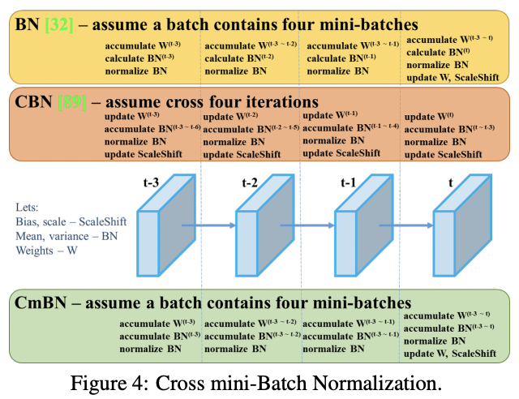

  - modified SAM(Spatial Attention Module), modified PAN(Path Aggregation Network)
    - SAM을 spatial-wise > point-wise로 변경
    - PAN의 shortcut connection > concatenation으로

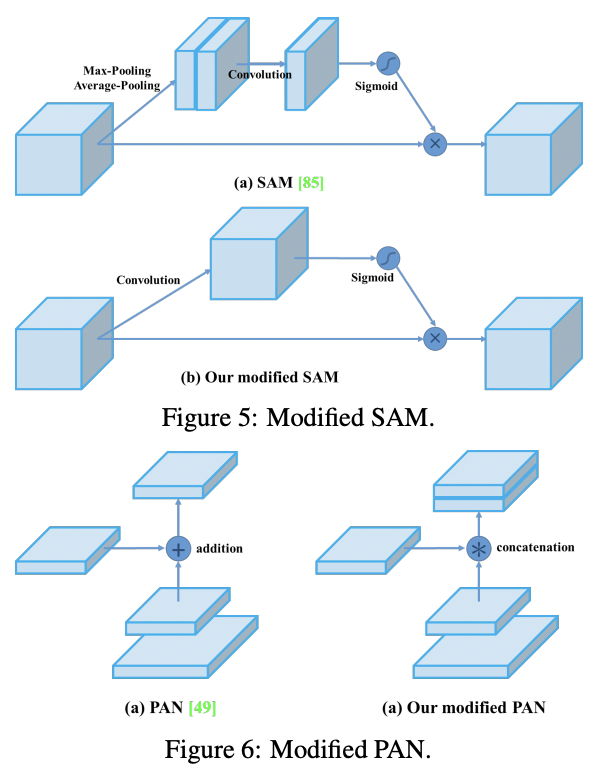

**4. YOLO v4 architecture**

- CSPDarknet53
- SPP + PAN
- YOLO v3
- Many BoF + Bos feautres
- BoF
- for backbone
  - data augmentation : CutMix, Mosaic
  - imbalance sampling : Class labeling smoothing
  - regularization : DropBlock
- for detector
  - object function : CIoU loss
  - normalization of network activation : CmBN
  - regularization : DropBlock
  - data augmentation : Mosic, Self-Adversarial Training(SAT)
  - hyper-parameters optimization : Genetic algorithms
  - learning rate scheduler : Cosine annealing scheduler
  - others
    - Eliminate grid sensitivity
    - Using multiple anchors for a single ground truth
    - Random training Shapes.
- BoS
  - for backbone
    - activation function : Mish
    - skep-connection : CSP, MiWRC
  - for detector
    - activation function : Mish
    - receptive field enhancement : SPP
    - attention : SAM
    - feature integration : PAN
    - post-processing : DIoU NMS

**용어 정리**

- ASFF : Adaptively Spatial Feature Fusion
- ASPP : Atrous Spatial Pyramid Pooling
- BiFPN : Bidirectional Feature Pyramid Network
- CBN : Cross-iteration Batch Normalization
- CmBN : Cross mini-Batch Normalization
- CSP : Cross-Stage-Partial-connections
- FCOS : Fully Convolutional One-Stage pbject detector
- MiWRC : Multi-input-Weighted-Residual-Connections
- NAS-FPN : Neural Architecture Search Feature Pyramid Network
- PAN : Path Aggregation Network
- RFB : Receptive Field Block
- SAM : Spatial Attention Module
- SAT : Self-Adversarial-Training
- SE : Squeeze-and-Exitation
- SFAM : Scale-wise-Feature-Aggregation Module
- SPP : Spatial Pyramid Pooling